# CPR Study: Statistical Analysis

## Data Preprocessing

```r
data_file = "20210307 Master_TCAD_Final_20210306_assumed less severe acc_use for overall CPR_unique3.csv"
data_combined_subset = read.csv(data_file)
```

- If any of TSP CDR FCI is assumed, make TKT = 2

```r
data_combined_subset <- data_combined_subset %>%
  mutate(TKT = replace(TKT, (Is.TSP.Assumed==1) + (Is.CDR.Assumed==1) +
                         (Is.FCI.assumed==1) > 0, 2))
```

- Create Interaction Terms

```r
data_combined_subset <- data_combined_subset %>%
  mutate(TSP_IOF = TSP * IOF) %>%
  mutate(IOF_IOFB = IOF * IOFB) %>%
  mutate(TCL_TCLB = TCL * TCLB) %>%
  mutate(TCLsubFCI = TCL - FCI) %>%
  mutate(TSP_CDR = TSP * CDR) %>%
  mutate(TSPC_CDR = TSPC * CDR) %>%
  mutate(EIS_CDR = EIS.N * CDR)
```

- Manually assigning categorical variable types

```r
cat_vars = c("TKT", "ACT", "HMS", "SMS", "THT",
              "TFP", "TFN", "JKTHSTBB", "JKTHSTrev",
             "IOFB", "TCLB")
data_combined_subset[, cat_vars] = lapply(data_combined_subset[, cat_vars],
                                          factor)
```

- Set reference variables(levels) for dummy variables

```r
data_combined_subset <- data_combined_subset %>%
  mutate(ACT = relevel(ACT, ref="1")) %>%
  mutate(THT = relevel(THT, ref="0")) %>%
  mutate(SMS = relevel(SMS, ref="515")) %>%
  mutate(TFP = relevel(TFP, ref="U")) %>%
  mutate(TFN = relevel(TFN, ref="1")) %>%
  mutate(HMS = relevel(HMS, ref="515")) %>%
  mutate(JKTHSTBB = relevel(JKTHSTBB, ref="0")) %>%
  mutate(JKTHSTrev = relevel(JKTHSTrev, ref="0"))
```

- HMS Binary variable: 1 for 128 and 516, 0 for 515

```r
data_combined_subset <- data_combined_subset %>%
  mutate(HMSB = ifelse(HMS == '515', 0, 1)) %>%
  mutate(SMSB = ifelse(SMS == '515', 0, 1))
```

- Add internations terms (2021/02/15)

```r
data_combined_subset <- data_combined_subset %>%
  mutate(TSPS = TSP * TSP) %>%
  mutate(EISS = EIS.N * EIS.N) %>%
  mutate(TSPS_CDR = TSPS * CDR) %>%
  mutate(EIS_IOF = EIS.N * IOF) %>%
  mutate(TSPS_IOF = TSPS * IOF) %>%
  mutate(TSPC_IOF = TSPC * IOF) %>%
  mutate(EISS_IOF = EISS * IOF) %>%
  mutate(EISS_CDR = EISS * CDR) %>%
  mutate(TSPC_CDR = TSPC * CDR)
```

- Check for Missing Values in TKT? No missing values.

```r
sum(is.na(data_combined_subset$TKT))
```

```
[1] 0
```

- Form `combined_data`

```r
var_names <- c("TSP","CDR","JKTHSTBB","TSP_IOF","EIS.N","ACT","HMSB",
               "HID","HMT","Z.indicator","THT","IOF","LDLH","TSPS",
               "EISS","TSP_CDR","TSPS_CDR","EIS_IOF","JKT","STS",
               "SID","EIS_CDR", "LDLS","TSPS_IOF","TSPC","SMSB","TFPB",
               "TSPC_CDR", "LDLT", "LDLB", "NewResponse")
combined_data <- data_combined_subset %>%
  filter(SUBH==1 & SUBS==1 & SUBT==1 & SUBB==1) %>%
   select(var_names)
```

- Split data into training and testing data

```r
set.seed(1231)
train_id <- combined_data$NewResponse %>%
  createDataPartition(p=0.8,list=FALSE)
train_combined <- combined_data[train_id, ]
test_combined <- combined_data[-train_id, ]
#combined_x <- model.matrix(NewResponse~ ., data = train_combined)[,-1]
#combined_y=train_combined$NewResponse
```

## Head

### Logistc Model

Logistic Regressions with variables selected from LASSO; LASSO variables are selected in prior analysis.

```r
head_lasso_vars <- c('TSP', 'CDR', 'JKTHSTBB', 'TSP_IOF', 'EIS.N',
                    'ACT', 'HMSB', 'HID', 'HMT', 'Z.indicator')
head_data_logit <- glm(formula = LDLH ~ .,
                    family = binomial,
                    data = train_combined[, c('LDLH', head_lasso_vars)])
summary(head_data_logit)
```

```
Call:
glm(formula = LDLH ~ ., family = binomial, data = train_combined[,
    c("LDLH", head_lasso_vars)])

Deviance Residuals:
    Min       1Q   Median       3Q      Max
-1.4884  -0.1704  -0.0938  -0.0600   3.6147

Coefficients:
              Estimate Std. Error z value Pr(>|z|)
(Intercept) -0.6795427  2.1077068  -0.322  0.74714
TSP          0.0325975  0.0139049   2.344  0.01906 *
CDR          0.0297909  0.0103693   2.873  0.00407 **
JKTHSTBB1   -0.7159129  0.7671369  -0.933  0.35070
JKTHSTBB2   -1.5600478  0.2023180  -7.711 1.25e-14 ***
JKTHSTBB3   -2.2117594  0.7681332  -2.879  0.00398 **
TSP_IOF     -0.0001091  0.0014016  -0.078  0.93794
EIS.N        0.0048455  0.0119095   0.407  0.68411
ACT2         1.4722635  0.2489308   5.914 3.33e-09 ***
HMSB        -0.8632564  0.2186893  -3.947 7.90e-05 ***
HID         -0.0133736  0.0155455  -0.860  0.38963
HMT         -2.7632597  2.0684451  -1.336  0.18158
Z.indicator -1.3525683  0.2347706  -5.761 8.35e-09 ***
---
Signif. codes:  0 ‘***’ 0.001 ‘**’ 0.01 ‘*’ 0.05 ‘.’ 0.1 ‘ ’ 1

(Dispersion parameter for binomial family taken to be 1)

    Null deviance: 1461.2  on 8075  degrees of freedom
Residual deviance: 1091.5  on 8063  degrees of freedom
AIC: 1117.5

Number of Fisher Scoring iterations: 8
```

### Evaluation

- AUC

```r
log_predict <- predict(head_data_logit,
                       newdata = test_combined,
                       type = "response")
auc(test_combined$LDLH, log_predict)
```

```
[1] 0.890448
```

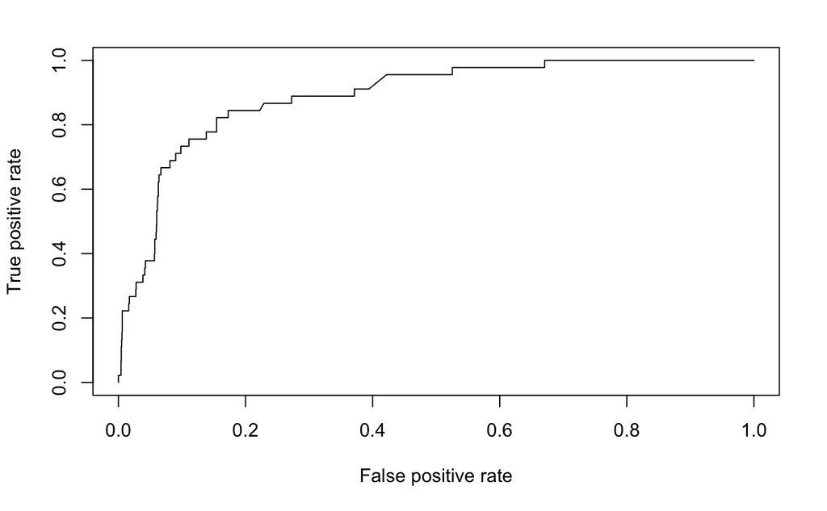

```r
pr=prediction(log_predict, test_combined$LDLH)
perf=performance(pr, measure="tpr", x.measure="fpr")
plot(perf)
```

- Predictive Accuracy

```r
yHat = head_data_logit$fitted.values > 0.5
tab = table(train_combined$LDLH, yHat)
print(tab)
```

```
   yHat
    FALSE TRUE
  0  7926    4
  1   143    3
```

```r
sum(diag(tab))/sum(tab)
```

```
[1] 0.9817979
```

```r
testyHat = log_predict > 0.5
tab = table(test_combined$LDLH, testyHat)
print(tab)
```

```
   testyHat
    FALSE TRUE
  0  1970    4
  1    44    1
```

```r
sum(diag(tab))/sum(tab)
```

```
[1] 0.9762259
```

- McFadden’s Pseudo R^2? (Deviance)

```r
r2Log <- function(model) {
  summaryLog <- summary(model)
  1 - summaryLog$deviance / summaryLog$null.deviance
}
r2Log(head_data_logit)
```

```
[1] 0.2529907
```

## Shell

### Logistc Model

Logistic Regressions with variables selected from LASSO; LASSO variables are selected in prior analysis.

```r
shell_lasso_vars <- c('TSP', 'CDR', 'JKT', 'IOF', 'TSP_IOF', 'EIS.N',
                      'ACT', 'STS', 'SID', 'THT', 'EIS_CDR', 'Z.indicator')
shell_data_logit <- glm(formula = LDLS ~ .,
                        family = binomial,
                        data = train_combined[, c('LDLS', shell_lasso_vars)])
summary(shell_data_logit)
```

```
Call:
glm(formula = LDLS ~ ., family = binomial, data = train_combined[,
    c("LDLS", shell_lasso_vars)])

Deviance Residuals:
    Min       1Q   Median       3Q      Max
-1.4396  -0.1485  -0.0949  -0.0944   3.4933

Coefficients:
              Estimate Std. Error z value Pr(>|z|)
(Intercept) -2.2189355  1.8345907  -1.209 0.226471
TSP         -0.0087129  0.0231491  -0.376 0.706634
CDR          0.0675595  0.0169949   3.975 7.03e-05 ***
JKT         -0.9061764  0.3128817  -2.896 0.003777 **
IOF          0.1861792  0.1075113   1.732 0.083324 .
TSP_IOF     -0.0006251  0.0029179  -0.214 0.830378
EIS.N        0.0823341  0.0180148   4.570 4.87e-06 ***
ACT2        -0.0495634  0.4466710  -0.111 0.911647
STS         -5.8190302  1.9917836  -2.922 0.003483 **
SID         -0.0040154  0.0137326  -0.292 0.769981
THT1        -0.1991927  0.3216049  -0.619 0.535672
EIS_CDR     -0.0010644  0.0004160  -2.558 0.010514 *
Z.indicator -0.9120244  0.2552347  -3.573 0.000353 ***
---
Signif. codes:  0 ‘***’ 0.001 ‘**’ 0.01 ‘*’ 0.05 ‘.’ 0.1 ‘ ’ 1

(Dispersion parameter for binomial family taken to be 1)

    Null deviance: 1587.3  on 8075  degrees of freedom
Residual deviance: 1126.0  on 8063  degrees of freedom
AIC: 1152

Number of Fisher Scoring iterations: 8
```

### Evaluation

- AUC

```r
log_predict <- predict(shell_data_logit,
                       newdata = test_combined,
                       type = "response")
auc(test_combined$LDLS, log_predict)
```

```
[1] 0.9166787
```

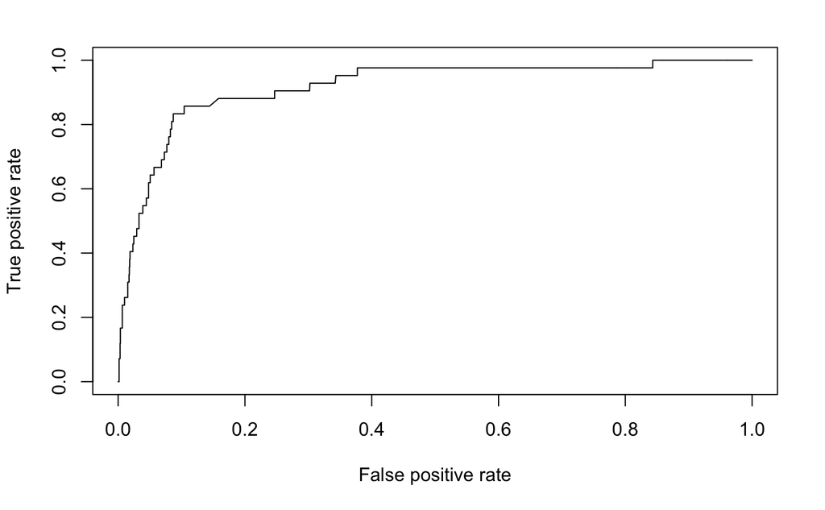

```r
pr <- prediction(log_predict, test_combined$LDLS)
perf <- performance(pr, measure="tpr", x.measure="fpr")
plot(perf)
```

- Predictive Accuracy

```r
yHat = shell_data_logit$fitted.values > 0.5
tab = table(train_combined$LDLS, yHat)
print(tab)
```

```
   yHat
    FALSE TRUE
  0  7903   11
  1   148   14
```

```r
sum(diag(tab))/sum(tab)
```

```
[1] 0.980312
```

```r
testyHat = log_predict > 0.5
tab = table(test_combined$LDLS, testyHat)
print(tab)
```

```
   testyHat
    FALSE TRUE
  0  1973    4
  1    39    3
```

```r
sum(diag(tab))/sum(tab)
```

```
[1] 0.9787023
```

- McFadden’s Pseudo R^2? (Deviance)

```r
r2Log(shell_data_logit)
```

```
[1] 0.290617
```

## Top

### Logistc Model

Logistic Regressions with variables selected from LASSO; LASSO variables are selected in prior analysis.

```r
top_lasso_vars <- c('TSP', 'TSPC', 'CDR', 'JKT', 'IOF', 'TSP_IOF', 'EIS.N',
                    'ACT', 'SMSB', 'STS', 'TFPB', 'TSP_CDR', 'TSPC_CDR',
                    'EIS_CDR', 'Z.indicator')
top_data_logit <- glm(formula = LDLT ~ .,
                      family = binomial,
                      data = train_combined[, c('LDLT', top_lasso_vars)])
summary(top_data_logit)
```

```
Call:
glm(formula = LDLT ~ ., family = binomial, data = train_combined[,
    c("LDLT", top_lasso_vars)])

Deviance Residuals:
    Min       1Q   Median       3Q      Max
-1.6926  -0.2664  -0.1303  -0.0952   3.5644

Coefficients:
              Estimate Std. Error z value Pr(>|z|)
(Intercept) -3.8600384  1.0526368  -3.667 0.000245 ***
TSP         -0.0657693  0.0345601  -1.903 0.057035 .
TSPC         1.1806976  0.5862289   2.014 0.044004 *
CDR          0.1892179  0.0856372   2.210 0.027138 *
JKT         -1.4133546  0.1218927 -11.595  < 2e-16 ***
IOF         -0.1498312  0.0806894  -1.857 0.063327 .
TSP_IOF      0.0032637  0.0023297   1.401 0.161244
EIS.N        0.0230410  0.0184404   1.249 0.211488
ACT2        -0.2813920  0.2279342  -1.235 0.217005
SMSB        -0.6291469  0.1359300  -4.628 3.68e-06 ***
STS          1.9280053  1.0742434   1.795 0.072693 .
TFPB        -0.6792415  0.2114716  -3.212 0.001318 **
TSP_CDR      0.0018116  0.0013081   1.385 0.166098
TSPC_CDR    -0.0703598  0.0386949  -1.818 0.069015 .
EIS_CDR      0.0001855  0.0005501   0.337 0.735971
Z.indicator -2.5549915  0.1880491 -13.587  < 2e-16 ***
---
Signif. codes:  0 ‘***’ 0.001 ‘**’ 0.01 ‘*’ 0.05 ‘.’ 0.1 ‘ ’ 1

(Dispersion parameter for binomial family taken to be 1)

    Null deviance: 2875.5  on 8075  degrees of freedom
Residual deviance: 2189.4  on 8060  degrees of freedom
AIC: 2221.4

Number of Fisher Scoring iterations: 7
```

### Evaluation

- AUC

```r
log_predict <- predict(top_data_logit,
                       newdata = test_combined,
                       type = "response")
auc(test_combined$LDLT, log_predict)
```

```
[1] 0.8511619
```

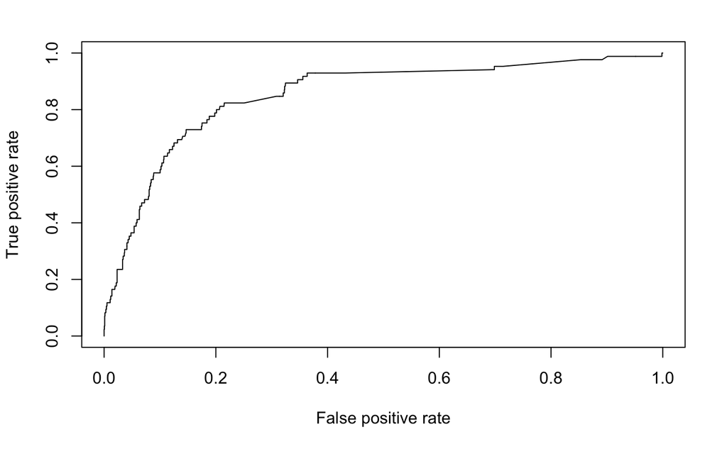

```r
pr <- prediction(log_predict, test_combined$LDLT)
perf <- performance(pr, measure="tpr", x.measure="fpr")
plot(perf)
```

- Predictive Accuracy

```r
yHat = top_data_logit$fitted.values > 0.5
tab = table(train_combined$LDLT, yHat)
print(tab)
```

```
   yHat
    FALSE TRUE
  0  7713   14
  1   329   20
```

```r
sum(diag(tab))/sum(tab)
```

```
[1] 0.9575285
```

```r
testyHat = log_predict > 0.5
tab = table(test_combined$LDLT, testyHat)
print(tab)
```

```
   testyHat
    FALSE TRUE
  0  1927    7
  1    77    8
```

```r
sum(diag(tab))/sum(tab)
```

```
[1] 0.9583952
```

- McFadden’s Pseudo R^2? (Deviance)

```r
r2Log(top_data_logit)
```

```
[1] 0.2386153
```

## Bottom

### Logistc Model

Logistic Regressions with variables selected from LASSO; LASSO variables are selected in prior analysis.

```r
bottom_lasso_vars <- c('CDR', 'JKT', 'TSP_IOF', 'EIS.N', 'ACT', 'STS',
                       'EIS_CDR', 'Z.indicator')
bottom_data_logit <- glm(formula = LDLB ~ .,
                         family = binomial,
                         data = train_combined[, c('LDLB', bottom_lasso_vars)])
summary(bottom_data_logit)
```

```
Call:
glm(formula = LDLB ~ ., family = binomial, data = train_combined[,
    c("LDLB", bottom_lasso_vars)])

Deviance Residuals:
    Min       1Q   Median       3Q      Max
-1.2274  -0.1701  -0.0887  -0.0887   3.6171

Coefficients:
              Estimate Std. Error z value Pr(>|z|)
(Intercept) -0.1000294  1.1053175  -0.090 0.927891
CDR          0.0519233  0.0156135   3.326 0.000882 ***
JKT         -1.4082077  0.1829826  -7.696 1.41e-14 ***
TSP_IOF     -0.0003030  0.0010836  -0.280 0.779793
EIS.N        0.0679080  0.0108807   6.241 4.34e-10 ***
ACT2        -0.8501502  0.5245792  -1.621 0.105096
STS         -8.0882611  2.4178784  -3.345 0.000822 ***
EIS_CDR     -0.0011613  0.0003299  -3.520 0.000432 ***
Z.indicator -1.6085314  0.2372838  -6.779 1.21e-11 ***
---
Signif. codes:  0 ‘***’ 0.001 ‘**’ 0.01 ‘*’ 0.05 ‘.’ 0.1 ‘ ’ 1

(Dispersion parameter for binomial family taken to be 1)

    Null deviance: 1453.2  on 8075  degrees of freedom
Residual deviance: 1116.8  on 8067  degrees of freedom
AIC: 1134.8

Number of Fisher Scoring iterations: 8
```

### Evaluation

- AUC

```r
log_predict <- predict(bottom_data_logit,
                       newdata = test_combined,
                       type = "response")
auc(test_combined$LDLB, log_predict)
```

```
[1] 0.9087565
```

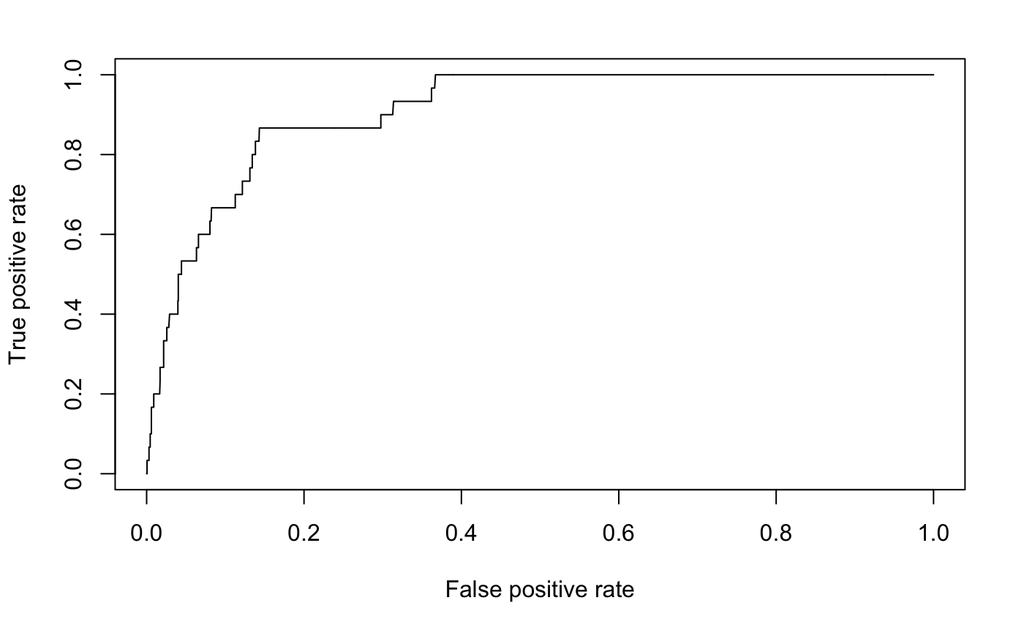

```r
pr <- prediction(log_predict, test_combined$LDLB)
perf <- performance(pr, measure="tpr", x.measure="fpr")
plot(perf)
```

- Predictive Accuracy

```r
yHat = bottom_data_logit$fitted.values > 0.5
tab = table(train_combined$LDLB, yHat)
print(tab)
```

```
   yHat
    FALSE TRUE
  0  7930    1
  1   145    0
```

```r
sum(diag(tab))/sum(tab)
```

```
[1] 0.9819217
```

```r
testyHat = log_predict > 0.5
tab = table(test_combined$LDLB, testyHat)
print(tab)
```

```
   testyHat
    FALSE
  0  1989
  1    30
```

```r
sum(diag(tab))/sum(tab)
```

```
[1] 0.9851412
```

- McFadden’s Pseudo R^2? (Deviance)

```r
r2Log(bottom_data_logit)
```

```
[1] 0.2314405
```

## Overal CPR

- Logistic Regression with variables selected from LASSO - combined data

```r
head_data_logit <- glm(formula = LDLH ~ .,
                    family = binomial,
                    data = combined_data[, c('LDLH', head_lasso_vars)])
summary(head_data_logit)
```

```
Call:
glm(formula = LDLH ~ ., family = binomial, data = combined_data[,
    c("LDLH", head_lasso_vars)])

Deviance Residuals:
    Min       1Q   Median       3Q      Max
-1.5029  -0.1748  -0.0958  -0.0601   3.6110

Coefficients:
              Estimate Std. Error z value Pr(>|z|)
(Intercept) -0.5398589  1.8068192  -0.299  0.76510
TSP          0.0250153  0.0128367   1.949  0.05133 .
CDR          0.0290264  0.0091050   3.188  0.00143 **
JKTHSTBB1   -0.9081076  0.7543038  -1.204  0.22863
JKTHSTBB2   -1.4888577  0.1765754  -8.432  < 2e-16 ***
JKTHSTBB3   -1.5177770  0.5170167  -2.936  0.00333 **
TSP_IOF      0.0004774  0.0012674   0.377  0.70641
EIS.N        0.0092863  0.0107379   0.865  0.38714
ACT2         1.4254060  0.2201720   6.474 9.54e-11 ***
HMSB        -0.8953220  0.1931962  -4.634 3.58e-06 ***
HID         -0.0167841  0.0135414  -1.239  0.21517
HMT         -2.1608529  1.7121662  -1.262  0.20693
Z.indicator -1.3685550  0.2089236  -6.551 5.73e-11 ***
---
Signif. codes:  0 ‘***’ 0.001 ‘**’ 0.01 ‘*’ 0.05 ‘.’ 0.1 ‘ ’ 1

(Dispersion parameter for binomial family taken to be 1)

    Null deviance: 1894.0  on 10094  degrees of freedom
Residual deviance: 1414.4  on 10082  degrees of freedom
AIC: 1440.4

Number of Fisher Scoring iterations: 8
```

```r
shell_data_logit <- glm(formula = LDLS ~ .,
                        family = binomial,
                        data = combined_data[, c('LDLS', shell_lasso_vars)])
summary(shell_data_logit)
```

```
Call:
glm(formula = LDLS ~ ., family = binomial, data = combined_data[,
    c("LDLS", shell_lasso_vars)])

Deviance Residuals:
    Min       1Q   Median       3Q      Max
-1.3483  -0.1428  -0.0928  -0.0924   3.4861

Coefficients:
              Estimate Std. Error z value Pr(>|z|)
(Intercept) -3.0822176  1.5973292  -1.930  0.05366 .
TSP         -0.0054327  0.0206676  -0.263  0.79266
CDR          0.0682754  0.0152348   4.482 7.41e-06 ***
JKT         -0.7818591  0.2756619  -2.836  0.00456 **
IOF          0.1916579  0.0989318   1.937  0.05271 .
TSP_IOF     -0.0010101  0.0026184  -0.386  0.69966
EIS.N        0.0878496  0.0158238   5.552 2.83e-08 ***
ACT2        -0.1263002  0.4107864  -0.307  0.75849
STS         -4.4514005  1.6270456  -2.736  0.00622 **
SID         -0.0035605  0.0119705  -0.297  0.76613
THT1        -0.2444305  0.2884031  -0.848  0.39670
EIS_CDR     -0.0011723  0.0003605  -3.252  0.00115 **
Z.indicator -0.9376246  0.2366051  -3.963 7.41e-05 ***
---
Signif. codes:  0 ‘***’ 0.001 ‘**’ 0.01 ‘*’ 0.05 ‘.’ 0.1 ‘ ’ 1

(Dispersion parameter for binomial family taken to be 1)

    Null deviance: 1995.7  on 10094  degrees of freedom
Residual deviance: 1401.1  on 10082  degrees of freedom
AIC: 1427.1

Number of Fisher Scoring iterations: 8
```

```r
top_data_logit <- glm(formula = LDLT ~ .,
                      family = binomial,
                      data = combined_data[, c('LDLT', top_lasso_vars)])
summary(top_data_logit)
```

```
Call:
glm(formula = LDLT ~ ., family = binomial, data = combined_data[,
    c("LDLT", top_lasso_vars)])

Deviance Residuals:
    Min       1Q   Median       3Q      Max
-1.7491  -0.2711  -0.1278  -0.0967   3.5338

Coefficients:
              Estimate Std. Error z value Pr(>|z|)
(Intercept) -3.9643531  0.9312055  -4.257 2.07e-05 ***
TSP         -0.0600053  0.0310251  -1.934  0.05310 .
TSPC         1.2614299  0.5252918   2.401  0.01633 *
CDR          0.2148689  0.0784844   2.738  0.00619 **
JKT         -1.4049876  0.1093910 -12.844  < 2e-16 ***
IOF         -0.1339529  0.0730887  -1.833  0.06684 .
TSP_IOF      0.0027231  0.0021172   1.286  0.19840
EIS.N        0.0117042  0.0169085   0.692  0.48881
ACT2        -0.4090303  0.2095958  -1.952  0.05100 .
SMSB        -0.5598849  0.1212985  -4.616 3.92e-06 ***
STS          1.8828435  0.9179465   2.051  0.04025 *
TFPB        -0.6018811  0.1846817  -3.259  0.00112 **
TSP_CDR      0.0021265  0.0012205   1.742  0.08145 .
TSPC_CDR    -0.0878106  0.0352998  -2.488  0.01286 *
EIS_CDR      0.0006448  0.0005369   1.201  0.22982
Z.indicator -2.6024022  0.1691713 -15.383  < 2e-16 ***
---
Signif. codes:  0 ‘***’ 0.001 ‘**’ 0.01 ‘*’ 0.05 ‘.’ 0.1 ‘ ’ 1

(Dispersion parameter for binomial family taken to be 1)

    Null deviance: 3580.4  on 10094  degrees of freedom
Residual deviance: 2733.0  on 10079  degrees of freedom
AIC: 2765

Number of Fisher Scoring iterations: 7
```

```r
bottom_data_logit <- glm(formula = LDLB ~ .,
                         family = binomial,
                         data = combined_data[, c('LDLB', bottom_lasso_vars)])
summary(bottom_data_logit)
```

```
Call:
glm(formula = LDLB ~ ., family = binomial, data = combined_data[,
    c("LDLB", bottom_lasso_vars)])

Deviance Residuals:
    Min       1Q   Median       3Q      Max
-1.2326  -0.1622  -0.0869  -0.0869   3.6610

Coefficients:
              Estimate Std. Error z value Pr(>|z|)
(Intercept)  0.1486857  1.0617542   0.140 0.888630
CDR          0.0517407  0.0142608   3.628 0.000285 ***
JKT         -1.2703342  0.1664953  -7.630 2.35e-14 ***
TSP_IOF     -0.0002853  0.0009635  -0.296 0.767122
EIS.N        0.0707602  0.0098629   7.174 7.26e-13 ***
ACT2        -0.4354410  0.4047479  -1.076 0.282002
STS         -9.0600897  2.3304088  -3.888 0.000101 ***
EIS_CDR     -0.0011426  0.0002913  -3.923 8.75e-05 ***
Z.indicator -1.6483759  0.2218920  -7.429 1.10e-13 ***
---
Signif. codes:  0 ‘***’ 0.001 ‘**’ 0.01 ‘*’ 0.05 ‘.’ 0.1 ‘ ’ 1

(Dispersion parameter for binomial family taken to be 1)

    Null deviance: 1766.2  on 10094  degrees of freedom
Residual deviance: 1350.9  on 10086  degrees of freedom
AIC: 1368.9

Number of Fisher Scoring iterations: 8
```

- Create a new dataframe `combined_data2`

```r
combined_data2 = data.frame(NewResponse = combined_data$NewResponse)
combined_data2$cpr_head = head_data_logit$fitted.values
combined_data2$cpr_shell = shell_data_logit$fitted.values
combined_data2$cpr_top = top_data_logit$fitted.values
combined_data2$cpr_bottom = bottom_data_logit$fitted.values
```

- Split data into training and testing data

```r
set.seed(1231)
train_id2 = combined_data2$NewResponse %>%
  createDataPartition(p=0.8,list=FALSE)
train_combined2 = combined_data2[train_id2, ]
test_combined2 = combined_data2[-train_id2, ]
```

### All Interactions

- Train data

```r
run16_train_logit = glm(formula = NewResponse ~ cpr_head*cpr_shell*cpr_top*cpr_bottom,
                        family = binomial, data = train_combined2)
summary(run16_train_logit)
```

```
Call:
glm(formula = NewResponse ~ cpr_head * cpr_shell * cpr_top *
    cpr_bottom, family = binomial, data = train_combined2)

Deviance Residuals:
    Min       1Q   Median       3Q      Max
-3.1493  -0.3051  -0.2075  -0.1950   2.8764

Coefficients:
                                        Estimate Std. Error z value Pr(>|z|)
(Intercept)                              -4.2356     0.1023 -41.424  < 2e-16 ***
cpr_head                                 27.1250     3.6255   7.482 7.33e-14 ***
cpr_shell                                22.2644     3.8284   5.816 6.04e-09 ***
cpr_top                                  16.0641     1.2545  12.805  < 2e-16 ***
cpr_bottom                               19.9785     5.5177   3.621 0.000294 ***
cpr_head:cpr_shell                     -204.7004    43.2342  -4.735 2.19e-06 ***
cpr_head:cpr_top                       -115.1565    17.7913  -6.473 9.63e-11 ***
cpr_shell:cpr_top                       -92.7704    20.7077  -4.480 7.46e-06 ***
cpr_head:cpr_bottom                    -150.7128    56.1408  -2.685 0.007263 **
cpr_shell:cpr_bottom                   -113.2307    23.3314  -4.853 1.22e-06 ***
cpr_top:cpr_bottom                      -71.0390    25.6967  -2.765 0.005701 **
cpr_head:cpr_shell:cpr_top              932.1912   167.6854   5.559 2.71e-08 ***
cpr_head:cpr_shell:cpr_bottom           944.0156   186.7964   5.054 4.33e-07 ***
cpr_head:cpr_top:cpr_bottom             514.0856   165.1937   3.112 0.001858 **
cpr_shell:cpr_top:cpr_bottom            440.3182   102.3174   4.303 1.68e-05 ***
cpr_head:cpr_shell:cpr_top:cpr_bottom -3577.9605   597.5969  -5.987 2.13e-09 ***
---
Signif. codes:  0 ‘***’ 0.001 ‘**’ 0.01 ‘*’ 0.05 ‘.’ 0.1 ‘ ’ 1

(Dispersion parameter for binomial family taken to be 1)

    Null deviance: 4599.3  on 8075  degrees of freedom
Residual deviance: 3257.8  on 8060  degrees of freedom
AIC: 3289.8

Number of Fisher Scoring iterations: 6
```

- Evaluation

```r
# AUC
log_predict <- predict(run16_train_logit,
                       newdata = test_combined2,
                       type = "response")
auc(test_combined2$NewResponse, log_predict)
```

```
[1] 0.8731734
```

```r
#Predictive Accuracy
yHat = run16_train_logit$fitted.values>0.5
tab = table(train_combined2$NewResponse, yHat)
print(tab)
```

```
   yHat
    FALSE TRUE
  0  7349   61
  1   547  119
```

```r
sum(diag(tab))/sum(tab)
```

```
[1] 0.9247152
```

```r
testyHat = log_predict > 0.5
tab = table(test_combined2$NewResponse, testyHat)
print(tab)
```

```
   testyHat
    FALSE TRUE
  0  1825   26
  1   132   36
```

```r
sum(diag(tab))/sum(tab)
```

```
[1] 0.9217434
```

```r
#McFadden's Pseudo R^2? (Deviance)
r2Log(run16_train_logit)
```

```
[1] 0.2916837
```

### Combined Data

```r
run16_logit = glm(formula = NewResponse ~ cpr_head*cpr_shell*cpr_top*cpr_bottom,
                  family = binomial, data = combined_data2)
summary(run16_logit)
```

```
Call:
glm(formula = NewResponse ~ cpr_head * cpr_shell * cpr_top *
    cpr_bottom, family = binomial, data = combined_data2)

Deviance Residuals:
    Min       1Q   Median       3Q      Max
-3.6500  -0.3030  -0.2085  -0.1960   2.8856

Coefficients:
                                        Estimate Std. Error z value Pr(>|z|)
(Intercept)                           -4.221e+00  8.967e-02 -47.075  < 2e-16 ***
cpr_head                               2.720e+01  3.207e+00   8.481  < 2e-16 ***
cpr_shell                              2.167e+01  3.480e+00   6.226 4.80e-10 ***
cpr_top                                1.583e+01  1.095e+00  14.455  < 2e-16 ***
cpr_bottom                             1.961e+01  4.980e+00   3.939 8.19e-05 ***
cpr_head:cpr_shell                    -2.053e+02  3.878e+01  -5.294 1.20e-07 ***
cpr_head:cpr_top                      -1.115e+02  1.552e+01  -7.185 6.74e-13 ***
cpr_shell:cpr_top                     -8.552e+01  1.877e+01  -4.555 5.24e-06 ***
cpr_head:cpr_bottom                   -1.245e+02  4.715e+01  -2.641 0.008277 **
cpr_shell:cpr_bottom                  -1.010e+02  2.095e+01  -4.820 1.44e-06 ***
cpr_top:cpr_bottom                    -7.126e+01  2.300e+01  -3.098 0.001948 **
cpr_head:cpr_shell:cpr_top             8.440e+02  1.464e+02   5.767 8.08e-09 ***
cpr_head:cpr_shell:cpr_bottom          8.131e+02  1.409e+02   5.772 7.83e-09 ***
cpr_head:cpr_top:cpr_bottom            4.333e+02  1.259e+02   3.440 0.000581 ***
cpr_shell:cpr_top:cpr_bottom           3.866e+02  9.257e+01   4.177 2.96e-05 ***
cpr_head:cpr_shell:cpr_top:cpr_bottom -2.977e+03  4.382e+02  -6.794 1.09e-11 ***
---
Signif. codes:  0 ‘***’ 0.001 ‘**’ 0.01 ‘*’ 0.05 ‘.’ 0.1 ‘ ’ 1

(Dispersion parameter for binomial family taken to be 1)

    Null deviance: 5756.4  on 10094  degrees of freedom
Residual deviance: 4084.8  on 10079  degrees of freedom
AIC: 4116.8

Number of Fisher Scoring iterations: 6
```

- Overall CPR prediction on five cars

```r
newcars = data.frame(
  cpr_head = c(0.09118543, 0.04822973, 0.01818723, 0.01135243, 0.008959692),
  cpr_shell= c(0.1483996, 0.06365662, 0.06365662, 0.02931969, 0.0197362),
  cpr_top = c(0.348481, 0.1412546, 0.1412546, 0.07015777, 0.0668602),
  cpr_bottom = c(0.1291767, 0.04821325, 0.04821325, 0.01286633, 0)
)
rownames(newcars) = paste("run16_car", 1:5, sep='')
newcars$overall_cpr = predict(run16_logit, newcars, type = "response")
print(round(newcars, dig=4))
```

|  | cpr_head | cpr_shell | cpr_top | cpr_bottom | overall_cpr |
| --- | --- | --- | --- | --- | --- |
| run16_car1 | 0.0912 | 0.1484 | 0.3485 | 0.1292 | 0.5298 |
| run16_car2 | 0.0482 | 0.0637 | 0.1413 | 0.0482 | 0.2978 |
| run16_car3 | 0.0182 | 0.0637 | 0.1413 | 0.0482 | 0.2726 |
| run16_car4 | 0.0114 | 0.0293 | 0.0702 | 0.0129 | 0.0886 |
| run16_car5 | 0.0090 | 0.0197 | 0.0669 | 0.0000 | 0.0631 |

### Pairwise

- Train data

```r
run16_train_logit_pair = glm(NewResponse ~.^2,
                             family = binomial, data = train_combined2)
summary(run16_train_logit_pair)
```

```
Call:
glm(formula = NewResponse ~ .^2, family = binomial, data = train_combined2)

Deviance Residuals:
    Min       1Q   Median       3Q      Max
-2.4668  -0.3070  -0.2398  -0.2319   2.7200

Coefficients:
                      Estimate Std. Error z value Pr(>|z|)
(Intercept)           -3.72547    0.07518 -49.552  < 2e-16 ***
cpr_head               8.43355    2.18056   3.868 0.000110 ***
cpr_shell              3.54709    2.64134   1.343 0.179299
cpr_top               13.01431    0.94097  13.831  < 2e-16 ***
cpr_bottom             8.86349    3.87847   2.285 0.022295 *
cpr_head:cpr_shell    42.77968   18.74241   2.283 0.022459 *
cpr_head:cpr_top     -35.09196    9.80556  -3.579 0.000345 ***
cpr_head:cpr_bottom  -27.35425   23.58262  -1.160 0.246076
cpr_shell:cpr_top     -1.36311   14.30958  -0.095 0.924109
cpr_shell:cpr_bottom -16.59513   11.07617  -1.498 0.134062
cpr_top:cpr_bottom   -21.41883   18.28598  -1.171 0.241468
---
Signif. codes:  0 ‘***’ 0.001 ‘**’ 0.01 ‘*’ 0.05 ‘.’ 0.1 ‘ ’ 1

(Dispersion parameter for binomial family taken to be 1)

    Null deviance: 4599.3  on 8075  degrees of freedom
Residual deviance: 3343.4  on 8065  degrees of freedom
AIC: 3365.4

Number of Fisher Scoring iterations: 6
```

- Evaluation

```r
#AUC
log_predict <- predict(run16_train_logit_pair, newdata = test_combined2,
                       type = "response")
auc(test_combined2$NewResponse, log_predict)
```

```
[1] 0.8767204
```

```r
#Predictive Accuracy
yHat = run16_train_logit_pair$fitted.values > 0.5
tab = table(train_combined2$NewResponse, yHat)
print(tab)
```

```
   yHat
    FALSE TRUE
  0  7281  129
  1   468  198
```

```r
sum(diag(tab))/sum(tab)
```

```
[1] 0.9260773
```

```r
testyHat = log_predict > 0.5
tab = table(test_combined2$NewResponse, testyHat)
print(tab)
```

```
   testyHat
    FALSE TRUE
  0  1799   52
  1   119   49
```

```r
sum(diag(tab))/sum(tab)
```

```
[1] 0.9153046
```

```r
#McFadden's Pseudo R^2? (Deviance)
r2Log(run16_train_logit_pair)
```

```
[1] 0.2730676
```

- Combine Data

```r
run16_logit_pair = glm(NewResponse ~.^2,
                             family = binomial, data = combined_data2)
summary(run16_logit_pair)
```

```
Call:
glm(formula = NewResponse ~ .^2, family = binomial, data = combined_data2)

Deviance Residuals:
    Min       1Q   Median       3Q      Max
-2.4050  -0.3088  -0.2439  -0.2366   2.7097

Coefficients:
                      Estimate Std. Error z value Pr(>|z|)
(Intercept)           -3.68154    0.06585 -55.911  < 2e-16 ***
cpr_head               6.32273    1.88969   3.346  0.00082 ***
cpr_shell              3.81698    2.31841   1.646  0.09969 .
cpr_top               12.69794    0.82124  15.462  < 2e-16 ***
cpr_bottom             9.17149    3.42038   2.681  0.00733 **
cpr_head:cpr_shell    33.07788   15.73925   2.102  0.03559 *
cpr_head:cpr_top     -25.33163    8.48668  -2.985  0.00284 **
cpr_head:cpr_bottom  -24.73757   20.72413  -1.194  0.23261
cpr_shell:cpr_top     -0.90623   12.71632  -0.071  0.94319
cpr_shell:cpr_bottom -13.70521    9.94185  -1.379  0.16804
cpr_top:cpr_bottom   -24.58907   16.21251  -1.517  0.12935
---
Signif. codes:  0 ‘***’ 0.001 ‘**’ 0.01 ‘*’ 0.05 ‘.’ 0.1 ‘ ’ 1

(Dispersion parameter for binomial family taken to be 1)

    Null deviance: 5756.4  on 10094  degrees of freedom
Residual deviance: 4214.5  on 10084  degrees of freedom
AIC: 4236.5

Number of Fisher Scoring iterations: 6
```

- Overall CPR prediction on five cars based on pairwise model

```r
newcars$overall_cpr_pairwise = predict(run16_logit_pair, newcars, type = "response")
print(round(newcars, dig=4))
```

|  | cpr_head | cpr_shell | cpr_top | cpr_bottom | overall_cpr | overall_cpr_pairwise |
| --- | --- | --- | --- | --- | --- | --- |
| run16_car1 | 0.0912 | 0.1484 | 0.3485 | 0.1292 | 0.5298 | 0.7322 |
| run16_car2 | 0.0482 | 0.0637 | 0.1413 | 0.0482 | 0.2978 | 0.2237 |
| run16_car3 | 0.0182 | 0.0637 | 0.1413 | 0.0482 | 0.2726 | 0.2052 |
| run16_car4 | 0.0114 | 0.0293 | 0.0702 | 0.0129 | 0.0886 | 0.0737 |
| run16_car5 | 0.0090 | 0.0197 | 0.0669 | 0.0000 | 0.0631 | 0.0623 |

### Triple

- Overall CPR prediction on five cars based on triple interaction model

```r
run16_logit_triple = glm(NewResponse ~.^3,
                             family = binomial, data = combined_data2)
newcars$overall_cpr_triple = predict(run16_logit_triple, newcars, type = "response")
print(round(newcars, dig=4))
```

|  | cpr_head | cpr_shell | cpr_top | cpr_bottom | overall_cpr | overall_cpr_pairwise | overall_cpr_triple |
| --- | --- | --- | --- | --- | --- | --- | --- |
| run16_car1 | 0.0912 | 0.1484 | 0.3485 | 0.1292 | 0.5298 | 0.7322 | 0.5973 |
| run16_car2 | 0.0482 | 0.0637 | 0.1413 | 0.0482 | 0.2978 | 0.2237 | 0.2765 |
| run16_car3 | 0.0182 | 0.0637 | 0.1413 | 0.0482 | 0.2726 | 0.2052 | 0.2459 |
| run16_car4 | 0.0114 | 0.0293 | 0.0702 | 0.0129 | 0.0886 | 0.0737 | 0.0796 |
| run16_car5 | 0.0090 | 0.0197 | 0.0669 | 0.0000 | 0.0631 | 0.0623 | 0.0609 |